# - no title specified

DR(20,30)=

(تعداد مرگ و میر در بازه سنی ۲۰ تا ۳۰ در یک سال بخصوص)/(میانگین جمعیت در بازه سنین ۲۰ تا ۳۰ در آن سال بخصوص)

محاسبه نرخ مرگ و میر به این شیوه معمولا لازم است از آنجاییکه همچین نرخ هایی تقریبا همیشه برای سنین مختلف بسیار فرق میکند، تغییراتی که توسط نرخ مرگ و میر خام آشکار نمی شود. همچنین به نرخ مرگ و میر بر اثر علت خاص و نسبت مرگ و میر استاندارد شده مراجعه کنید.

توافق: میزانی که ناظران، ارزیابان و آزمون های تشخیصی مختلف روی یک رده‌بندی دودویی توافق میکنند. معیار های توافق مانند ضریب کاپا، کمیت فراوانی نسبی درایه های قطر جدول توافقی دو در دو را با در نظر گرفتن توافق بر اثر شانس مشخص می

کنند. باید به این مسئله توجه کنید که توافق قوی نیازمند پیوند قوی است درصورتی که پیوند قوی نیازمند توافق قوی نیست.

آلفا اگرسی: یک تعمیم برای نسبت بخت ها از جدول توافقی دو در دو به جدول های توافقی بزرگتر است که ناشی شده از داده های است که درجه های مختلفی از شدت یک بیماری و مقدار های مختلف از آشکاری دارند.

میم. الف. الف.: مخفف معیار اطلاعات آکائیکه.

معیار اطلاعات آکائیکه: یک شاخص که در حوزه های مختلف برای انتخاب مدل استفاده می شود. تعریف می شود:

-2L+2m

به طوری که L ماکسیمم لگاریتم تابع درستنمایی و m تعداد پارامتر های مدل می باشد. این شاخص با ایجاد یک جریمه برای تعداد پارامتر های مدل، هم نکویی برازش آماری و هم تعداد پارامتر های مدل را در نظر می گیرد. مقادیر کمتر این شاخص نشان دهنده مدل بهتر است یعنی مدلی که با کمترین پارامتر، برازش

مناسبی برای داده ها تامین می کند. همچنین به اصل خساست(امساک) و معیار شوارتز مراجعه کنید.

الگوریتم: مجموعه ای از قوانین خوش تعریف است که اگر مرتب انجام شود به جواب یک مسئله از کلاس خاصی از مسائل ریاضی یا محاسباتی منجر می شود.

هم اثر سازی: زمانی اتفاق می‌افتد که برآورد یک پارامتر کاملاً با سایر پارامترها در هم آمیخته میشود زیرا اطلاعات کافی در دسترس نیست. هم اثر سازی بیرونی به دلیل کمبود داده کافی است مانند داده گمشده و یا همخطی. هم اثر سازی درونی به دلیل عدم شناسایی مدل آماری بخصوصی است، مثلا یک مدل رگرسیونی با متغیر توصیفی رسته ای که به اندازه دسته ها متغیر ظاهری دارد. (ماتریس X'X معکوس پذیر نمی باشد)

همه زیرمجموعه های رگرسیونی: یک نوع تحلیل رگرسیون است که در آن تمام مدل های ممکن در نظر گرفته می شود و بهترین مدل با مقایسه یک معیار مناسب مثل آماره cp مالو انتخاب میشود. اگر p تا

متغیر توصیفی داشته باشیم ، دو به توان p تا مدل باید بررسی شود. معمولا الگوریتم جست و خیز استفاده می شود تا تعداد کمی از مدل ها مورد بررسی قرار بگیرند. همچنین به روش های گزینش مدل در رگرسیون مراجعه کنید.

همگرایی تقریبا مطمئن: یک نوع همگرایی است که شبیه همگرایی نقطه ای یک دنباله از توابع می باشد با این تفاوت که همگرایی لازم نیست روی مجموعه های با احتمال صفر رخ دهد. تعریف رسمی آن به اینصورت است: دنباله Xt تقریبا با با اطمینان به mu میل میکند، اگر وجود داشته باشد مجموعه ای تحت عنوان M به طوری که P(M)=1 باشد و برای هر ω عضو N داشته باشیم X(ω) میل کند به mu.

آلفا: احتمال خطای نوع اول. همچنین به سطح معناداری مراجعه کنید.

آلفا پیراسته میانگین: یک روش برآورد کردن میانگین جامعه که نسبت به برآوردگر معمولیه میانگین نمونه، داده های پرت کمتر روی آن اثر می‌گذارند. نحوه

محاسبه آن به این صورت است که به اندازه نسبت آلفا از دو طرف مشاهدات حذف میکنیم و سپس از داده های باقیمانده میانگین میگیریم. اگر x(1),x(2),...,x(n) مقادیر مرتب شده نمونه باشند آنگاه این برآوردگر برابر

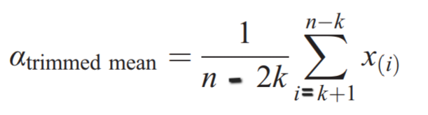

است که در آن k کوچک ترین عدد صحیح بزرگتر یا مساوی αn است. همچنین به برآوردگر های M مراجعه کنید.

[figure not shown]

به طوری که x(1),x(2),...x(n) مقادیر مرتب شده

نمونه هستند. همچنین به برآوردگر های M مراجعه کنید.

امید شرطی متناوب: یک روش برای برآورد کردن تبدیل بهینه برای آنالیز رگرسیون و همبستگی. برای متغیر های توصیفی x1,...xq و متغیر پاسخ y, این روش تبدیل g(y) و s1(x1) تا sq(xq) را پیدا میکند به طوری که این تبدیل، همبستگی بین y و مقادیر پیش‌بینی شده را بیشینه می کند. در این تکنیک هر تبدیل هموار دلخواهی را می توان برای متغیر های توصیفی و پاسخ استفاده کرد.

حداقل مربعات متناوب: روشی که اکثرا در مقیاس بندی چند بعدی استفاده میشود به طوری که یک معیار نکویی برازش برای برخی از پیکربندی های نقاط طی یک سری از مراحل کمینه میشود، که هر کدام شامل استفاده از حداقل مربعات است.

رگرسیون لجستیک متناوب: یک روش رگرسیون لجستیک که در تحلیل داده های طولی، زمانی که متغیر پاسخ دودویی باشد، استفاده میشود. بر پایه معادلات

برآورد تعمیم یافته.

فرض مقابل: فرضی که در برابر فرض صفر، آزمون میشود.

تحلیل کواریانس: در آغاز کار برای تعمیم آنالیز واریانس استفاده میشد به طوری که علاوه بر اثر متغیر های عامل، اثر ممکن متغیر پیوسته همراه (متغیر کمکی) را روی متغیر پاسخ در نظر میگیرد. معمولا فرض میشود که تیمار ها روی متغیر کمکی تاثیری ندارند و رابطه متغیر کمکی با متغیر پاسخ خطی است. اگر همچین رابطه ای وجود داشته باشد، آنگاه اضافه کردن متغیر کمکی میتواند منجر به کاهش میانگین مربع خطا شود و در نتیجه حساسیت آزمون F که برای ارزیابی تیمار ها به کار میرفت، افزایش یابد. امروزه به نظر میرسد که این اصطلاح عموما برای هر تحلیلی که در جستجوی ارزیابی رابطه بین متغیر پاسخ و چندین متغیر توصیفی باشد، به کار میرود. همچنین به توازی در تحلیل کواریانس ، مدل های خطی تعمیم یافته و تکنیک جانسون نیمن مراجعه کنید.

تحلیل پراکندگی: هم معنی تحلیل واریانس چندمتغیره است.

تحلیل واریانس: جداسازی واریانس قابل استناد به یک متغیر از واریانس قابل استناد به بقیه متغیر ها. با افراز واریانس کل مجموعه مشاهدات به بخش هایی مختص به عوامل مختلف، مثل، جنسیت، گروه تیمار و ...، و با مقایسه واریانس ها (مربعات میانگین) به کمک آزمون F، میتوان تفاوت بین میانگین ها را ارزیابی کرد. ساده ترین تحلیل از این نوع شامل یک طرح یک‌طرفه است که در آن N آزمودنی معمولاً به‌صورت تصادفی به k سطح مختلف یک عامل تخصیص می‌یابند. سپس تغییرات کل در مشاهدات به یک بخش ناشی از تفاوت‌های بین میانگین‌های سطوح (مجموع مربعات بین گروه‌ها) و یک بخش ناشی از تفاوت‌های بین آزمودنی در همان گروه (مجموع مربعات درون گروه‌ها، که همچنین به آن مجموع مربعات باقیمانده گفته می‌شود) تقسیم می‌شود. این اصطلاحات معمولاً به‌صورت یک جدول تحلیل واریانس تنظیم می‌شوند.

اگر میانگین‌های جمعیت‌های نماینده سطوح عامل

یکسان باشد، آنگاه در محدوده تغییرات تصادفی، میانگین مربعات بین گروه‌ها و میانگین مربعات درون گروه‌ها باید یکسان باشد. اینکه آیا این موضوع صحیح است یا نه، در صورتی که برخی فرضیات برآورده شوند، می‌تواند با یک آزمون F مناسب بر اساس نسبت میانگین مربعات ارزیابی شود. فرضیات ضروری برای اعتبار آزمون F این است که متغیر پاسخ در هر جامعه به‌طور نرمال توزیع شده و جامعه ها واریانس یکسانی داشته باشند. اساساً، این یک مثال از مدل خطی تعمیم‌یافته با تابع پیوند همانی و خطاهای با توزیع نرمال است. همچنین به تحلیل کوواریانس، طرح گروه‌های موازی و طرح های عاملی مراجعه کنید.

جدول تحلیل واریانس: به آنالیز واریانس مراجعه کنید.

آماره کمکی: اصطلاحی که به آماره C در موقعیت‌هایی اطلاق می‌شود که آماره بسنده مینیمال، S، برای پارامتر θ را می‌توان به صورت S=(T, C) نوشت و C دارای توزیع حاشیه‌ای است که به θ وابسته نیست. به عنوان مثال، بگذارید N یک متغیر تصادفی با توزیع شناخته شده pn = Pr(N = n)(n = 1, 2, ... ) باشد و

به طوری که S مساوی با [N,مجموع b(Yj)] برای تتا بسنده است و N آماره کمکی است. اصطلاحی مهم در کاربرد درستنمایی شرطی در برآورد.

به طوری که

فرض صفر نرمال بودن برای مقادیر 'بزرگ' An^2 رد می‌شود. مقادیر بحرانی آماره آزمون موجود است. همچنین به آزمون شاپیرو-ویلک مراجعه کنید.

برآوردگر اندرسون-شیائو: یک برآوردگر متغیرهای ابزاری برای مدل‌های داده‌های پانل دینامیک با تقاطع‌های خاص هر موضوع.

نمودار های اندرو: یک نمایش گرافیکی داده‌های چندمتغیره که در آن یک مشاهده

، x' = [x1, x2, ... , xq]

بر روی دامنه مقادیر

−π ≤ t ≤ π

روش شمارش زاویه ای: روشی برای برآورد نسبت مساحت یک جنگل که در واقع تحت پوشش پایه‌های درختان قرار دارد. یک ناظر به هر یک از چند نقطه در جنگل که به‌طور تصادفی یا سیستماتیک انتخاب شده‌اند، می‌رود و تعداد درختانی را که در آن نقطه، زاویه‌ای بزرگتر یا مساوی با زاویه ثابت از پیش تعیین شده ۲α را ایجاد می‌کنند، می‌شمارد.

(Bitterlich's method)

Angular histogram

intensive care unit=ICU

Angular uniform distribution

ت.و.: مخفف تحلیل واریانس.

باقیمانده انسکوب: جایگزینی برای باقیمانده‌های معمولی در مدل‌های رگرسیون که در آن‌ها مقادیر خطای تصادفی به‌طور نرمال توزیع نشده‌اند، مانند رگرسیون لجستیک. هدف تولید "باقیمانده‌هایی" است که توزیع‌هایی نزدیک به نرمال داشته باشند. شکل چنین باقیمانده‌ای به توزیع خطا فرض شده بستگی

دارد؛ به عنوان مثال، در مورد توزیع پواسون، شکل آن به صورت

3(y^(2/3)−ŷ^(2/3))/2ŷ^(1/6)

است که در آن y و ŷ به‌ترتیب مقادیر مشاهده‌شده و برازش‌یافته پاسخ هستند.

مدل های پادوابستگی: یک خانواده از ساختارها برای ماتریس واریانس-کواریانس یک مجموعه داده‌های طولی، با مدل مرتبه r که مستلزم این است که دنباله متغیرهای تصادفی، Y1، Y2، ...، YT به گونه‌ای باشد که برای هر r<t

Yt|Yt-1,Yt-2,... ,Yt-r

مستقل شرطی از Yt-r-1,..., Y1 است. به عبارت دیگر، پس از در نظر گرفتن r مشاهدات پیشین Yt، مشاهدات پیشین باقی‌مانده اطلاعات اضافی درباره Yt ارائه نمی‌دهند. این مدل هیچ محدودیتی بر ثبات واریانس یا همبستگی نسبت به زمان تحمیل نمی‌کند، بنابراین از نظر گشتاور مرتبه دوم، ایستا نیست. این ویژگی در عمل بسیار مفید است زیرا داده‌های بسیاری از مطالعات طولی اغلب با گذشت زمان واریانس افزایشی دارند.

اگر به عنوان مثال D1 = 2 باشد، در این صورت X2 کوچک‌ترین مقدار قدر مطلق و Z1 دارای رتبه 1 است.

متغیر متضاد: عبارتی که در برخی رویکردهای شبیه‌سازی به‌کار می‌رود، به طوری که اجرای متوالی شبیه‌سازی‌ها انجام می‌شود تا برآوردگرهای اجرای نااریب و با توزیع یکسان بدست آید که به‌جای مستقل بودن، همبستگی منفی دارند. ارزش این رویکرد در این است که منجر به یک برآوردگر نااریب (میانگین برآوردها از تمام اجراها) می‌شود که واریانس کمتری نسبت به میانگین برآوردهای اجرای با توزیع یکسان و مستقل دارد. به‌عنوان مثال، اگر r یک متغیر تصادفی بین ۰ و ۱ باشد، آنگاه s = 1 − r نیز همین‌طور خواهد بود. در اینجا دو اجرای شبیه‌سازی شامل

r1، r2، ...، rm

و

1 − r1، 1 − r2، ...، 1 − rm

خواهد بود که به‌وضوح مستقل نیستند.

طرح بهینه الف : به ملاک بهینگی مراجعه کنید.

ت.م.م.: مخفف تمام مقایسات موجود.

روش تخمین بازه اطمینان بوت استرپ: یک روش برای تخمین بازه اطمينان که از رویکرد بوت استرپ استفاده میکند و از هیچ گونه تکرار مونت کارلویی استفاده نمیکند.(یعنی لازم نیست نمونه جدید تولید کنی)

تخمین: یک نتیجه ای که دقیق نیست ولی به اندازه کافی نزدیک هست که برای اهداف خواسته شده مفید باشد.

Archetypal analysis

تحلیل کهن الگویی: رویکردی برای تحلیل داده‌های چندمتغیره که هدف آن نمایان کردن هر فرد در داده‌ها به عنوان ترکیبی از افراد با نوع خالص یا کهن الگو ها است. کهن الگو ها خود به ترکیبی از افراد موجود در مجموعه داده محدود می‌شوند. به طور

برای p > 1، کهن الگو ها بر روی پوسته محدب داده‌ها قرار می‌گیرند؛ آنها مقادیر فرین داده هستند به‌گونه‌ای که تمامی داده‌ها می‌توانند به‌عنوان ترکیب‌های محدب از کهن الگو ها نمایش داده شوند. با این حال، کهن الگو ها به‌طور کامل افسانه ای نیستند زیرا هرکدام محدود به ترکیبی از نقاط موجود در داده‌ها می‌باشند.

(unsupervised)

مدل های خ.ن.و.ش.: مخفف مدل های خودهمبسته ناهمواریانس شرطی.

توزیع آرک سینوسی: توزیع بتا با پارامتر های α=β=0.5

قانون آرک سینوس: یک تقریب قابل اعمال برای یک قدم‌زدن تصادفی ساده که مقادیر 1 و −1 را با احتمال 1/2 می‌گیرد است که محاسبه احتمال نسبت زمانی که امتیاز تجمعی مثبت یا منفی است را آسان می‌کند. این تقریب می‌تواند به این صورت بیان شود: برای α ثابت

(0 < α < 1)

و n به سمت بی‌نهایت، احتمال اینکه نسبت k/n از زمان، که امتیاز تجمعی مثبت است، کمتر از α باشد، به سمت

2π^-1arcsin(α^1/2)

(Pr(شیر)=Pr(خط)=۱/۲)

تبدیل آرک سینوس: یک تبدیل برای نسبت، p، که به منظور تثبیت واریانس آن طراحی شده و مقادیر مناسب‌تری برای تکنیک‌هایی مانند تحلیل واریانس و تحلیل رگرسیون تولید می‌کند. این تبدیل به صورت

ک.ن.م.: مخفف کارایی نسبی مجانبی.

نمونه گیری در سطح: روشی برای نمونه گیری که در آن یک منطقه جغرافیایی به نواحی کوچکتر (شهرستان‌ها، روستاها، بلوک‌های شهری و غیره) تقسیم می‌شود، که برخی از آن‌ها به‌صورت تصادفی انتخاب می‌شوند و سپس نواحی انتخاب‌شده یا زیر‌نمونه گیری می‌شوند یا به‌طور کامل مورد بررسی قرار می‌گیرند. به نمونه گیری خوشه‌ای نیز مراجعه کنید.

مساحت زیر نمودار (م.ز.ن.): اغلب یک راه مفید برای خلاصه‌سازی اطلاعات به دست آمده از مجموعه‌ای از اندازه‌گیری‌ها که در طول زمان بر روی یک فرد انجام می‌شود، مانند داده‌های جمع‌آوری شده در یک مطالعه طولی یا برای منحنی دوز-پاسخ است. معمولاً این کار با جمع کردن مساحت‌های زیر منحنی بین هر دو مشاهده متوالی محاسبه می‌شود، به عنوان مثال با استفاده از قاعده ذوزنقه. این روش اغلب

پیش‌بینی‌کننده اثرات بیولوژیکی مانند سمی بودن یا سودمندی است. همچنین به Cmax، تحلیل ویژگی‌های پاسخ و Tmax مراجعه کنید.

توزیع آرفویدسن: توزیع احتمال تعداد مقادیر صفر بین k متغیر تصادفی با توزیع چندجمله ای که p1=p2=...=pk.

خ.ی.م.: مخفف مدل های خودهمبسته یکپارچه میانگین متحرک.

میانگین حسابی: به میانگین مراجعه کن.

خ.م.م.: مخفف مدل های خودهمبسته میانگین متحرک.